# Lab 17: Vaccination rate mini project

Caroline Mackey (A15522472)

11/23/2021

## Background

We are investigating data on vaccination rates in California.

## Getting started

```r
# Import vaccination data

vax <- read.csv("covid19vaccinesbyzipcode_test.csv")
head(vax)
```

```
##   as_of_date zip_code_tabulation_area local_health_jurisdiction    county
## 1 2021-01-05                    92804                    Orange    Orange
## 2 2021-01-05                    92626                    Orange    Orange
## 3 2021-01-05                    92250                  Imperial  Imperial
## 4 2021-01-05                    92637                    Orange    Orange
## 5 2021-01-05                    92155                 San Diego San Diego
## 6 2021-01-05                    92259                  Imperial  Imperial
##   vaccine_equity_metric_quartile                 vem_source
## 1                              2 Healthy Places Index Score
## 2                              3 Healthy Places Index Score
## 3                              1 Healthy Places Index Score
## 4                              3 Healthy Places Index Score
## 5                             NA            No VEM Assigned
## 6                              1    CDPH-Derived ZCTA Score
##   age12_plus_population age5_plus_population persons_fully_vaccinated
```

[output cut: 34 more lines]

> **Q1.** What column details the total number of people fully vaccinated?

> **A1.** The column **persons_fully_vaccinated** details the total number of people fully vaccinated.

> **Q2.** What column details the Zip code tabulation area?

> **A2.** The column **zip_code_tabulation_area** details the Zip code tabulation area.

> **Q3.** What is the earliest date in this data set?

```r
vax$as_of_date[1]
```

```
## [1] "2021-01-05"
```

> **A3.** **2021-01-05** is the earliest date in the data set.

> **Q4.** What is the latest date in this data set?

```r
vax$as_of_date[nrow(vax)]
```

```
## [1] "2021-11-16"
```

> **A4.** **2021-11-16** is the latest date in the data set.

Use the **skim()** function to quickly overview & summarize the various columns of the data set.

```r
skimr::skim(vax)
```

Data summary

| Name | vax |
| --- | --- |
| Number of rows | 81144 |
| Number of columns | 14 |
| _______________________ |  |
| Column type frequency: |  |
| character | 5 |
| numeric | 9 |
| ________________________ |  |
| Group variables | None |

**Variable type: character**

| skim_variable | n_missing | complete_rate | min | max | empty | n_unique | whitespace |
| --- | --- | --- | --- | --- | --- | --- | --- |
| as_of_date | 0 | 1 | 10 | 10 | 0 | 46 | 0 |
| local_health_jurisdiction | 0 | 1 | 0 | 15 | 230 | 62 | 0 |
| county | 0 | 1 | 0 | 15 | 230 | 59 | 0 |
| vem_source | 0 | 1 | 15 | 26 | 0 | 3 | 0 |
| redacted | 0 | 1 | 2 | 69 | 0 | 2 | 0 |

**Variable type: numeric**

| skim_variable | n_missing | complete_rate | mean | sd | p0 | p25 | p50 | p75 | p100 | hist |
| --- | --- | --- | --- | --- | --- | --- | --- | --- | --- | --- |
| zip_code_tabulation_area | 0 | 1.00 | 93665.11 | 1817.39 | 90001 | 92257.75 | 93658.50 | 95380.50 | 97635.0 | ▃▅▅▇▁ |
| vaccine_equity_metric_quartile | 4002 | 0.95 | 2.44 | 1.11 | 1 | 1.00 | 2.00 | 3.00 | 4.0 | ▇▇▁▇▇ |
| age12_plus_population | 0 | 1.00 | 18895.04 | 18993.94 | 0 | 1346.95 | 13685.10 | 31756.12 | 88556.7 | ▇▃▂▁▁ |
| age5_plus_population | 0 | 1.00 | 20875.24 | 21106.05 | 0 | 1460.50 | 15364.00 | 34877.00 | 101902.0 | ▇▃▂▁▁ |
| persons_fully_vaccinated | 8256 | 0.90 | 9456.49 | 11498.25 | 11 | 506.00 | 4105.00 | 15859.00 | 71078.0 | ▇▂▁▁▁ |
| persons_partially_vaccinated | 8256 | 0.90 | 1900.61 | 2113.07 | 11 | 200.00 | 1271.00 | 2893.00 | 20185.0 | ▇▁▁▁▁ |
| percent_of_population_fully_vaccinated | 8256 | 0.90 | 0.42 | 0.27 | 0 | 0.19 | 0.44 | 0.62 | 1.0 | ▇▆▇▆▂ |
| percent_of_population_partially_vaccinated | 8256 | 0.90 | 0.10 | 0.10 | 0 | 0.06 | 0.07 | 0.11 | 1.0 | ▇▁▁▁▁ |
| percent_of_population_with_1_plus_dose | 8256 | 0.90 | 0.50 | 0.26 | 0 | 0.30 | 0.53 | 0.70 | 1.0 | ▅▅▇▇▃ |

> **Q5.** How many numeric columns are in this dataset?

```r
library("dplyr")
length(select_if(vax,is.numeric))
```

```
## [1] 9
```

> **A5.** There are **9** numeric columns in the vax data set.

> **Q6.** Note that there are “missing values” in the data set. How many NA values there in the persons_fully_vaccinated column?

```r
sum.na <- sum( is.na(vax$persons_fully_vaccinated) )
sum.na
```

```
## [1] 8256
```

Another method:

```r
summary(vax$persons_fully_vaccinated)
```

```
##    Min. 1st Qu.  Median    Mean 3rd Qu.    Max.    NA's
##      11     506    4105    9456   15859   71078    8256
```

> **A6.** There are **8256** missing values (i.e. “NA”s) in the persons_fully_vaccinated column.

> **Q7.** What percent of persons_fully_vaccinated values are missing (to 2 significant figures)?

```r
sum.na/nrow(vax)
```

```
## [1] 0.101745
```

> **A7.** Approximately **10.%** of persons_fully_vaccinated values are missing.

> **Q8.**
> $$Optional$$
> : Why might this data be missing?

> **A8.** One reason for the missing data could have been if there were issues reporting/ obtaining the data due to confidentiality.

## Working with dates

Use the **lubridate** package to make life a lot easier when dealing with dates & times.

```r
library(lubridate)
```

Make our `as_of_date` column lubridate format.

```r
# Specify that we are using the year-month-day format.
vax$as_of_date <- ymd(vax$as_of_date)
```

Now, we can do useful math with dates more easily.

```r
# Example
today() - vax$as_of_date[1]
```

```
## Time difference of 335 days
```

> **Original Q9.** How many days have passed since the last update of the data set?

```r
today()
```

```
## [1] "2021-12-06"
```

```r
today()- vax$as_of_date[nrow(vax)]
```

```
## Time difference of 20 days
```

> **New Q9.** How many days between the first & last enry in the dataset? (changed this question in class)

```r
# Last entry: vax$as_of_date[nrow(vax)]
# First entry: vax$as_of_date[1]
# Take the difference
vax$as_of_date[nrow(vax)]-vax$as_of_date[1]
```

```
## Time difference of 315 days
```

> **New A9.** **315 days** have passed between the first & last entry of the data set.

> **Q10.** How many unique dates are in the data set (i.e. how many different dates are detailed)?

```r
# unique(vax$as_of_date) prints all of the unique dates
# take the length of this to print how many
length(unique(vax$as_of_date))
```

```
## [1] 46
```

> **A10** There are **46** unique dates in the data set.

## Working with ZIP Codes

We will use the **zipcodeR** package to help make sense of the ZIP Code data.

```r
library(zipcodeR)
```

La Jolla ZIP Code:

```r
geocode_zip('92037')
```

```
## # A tibble: 1 × 3
##   zipcode   lat   lng
##   <chr>   <dbl> <dbl>
## 1 92037    32.8 -117.
```

Distance between 2 ZIP Codes:

```r
zip_distance('92037','92109')
```

```
##   zipcode_a zipcode_b distance
## 1     92037     92109     2.33
```

Census data:

```r
reverse_zipcode(c('92037', "92109") )
```

```
## # A tibble: 2 × 24
##   zipcode zipcode_type major_city post_office_city common_city_list county state
##   <chr>   <chr>        <chr>      <chr>                      <blob> <chr>  <chr>
## 1 92037   Standard     La Jolla   La Jolla, CA           <raw 20 B> San D… CA
## 2 92109   Standard     San Diego  San Diego, CA          <raw 21 B> San D… CA
## # … with 17 more variables: lat <dbl>, lng <dbl>, timezone <chr>,
## #   radius_in_miles <dbl>, area_code_list <blob>, population <int>,
## #   population_density <dbl>, land_area_in_sqmi <dbl>,
## #   water_area_in_sqmi <dbl>, housing_units <int>,
## #   occupied_housing_units <int>, median_home_value <int>,
## #   median_household_income <int>, bounds_west <dbl>, bounds_east <dbl>,
## #   bounds_north <dbl>, bounds_south <dbl>
```

```r
# Pull data for all ZIP codes in the dataset
# zipdata <- reverse_zipcode( vax$zip_code_tabulation_area )
```

## Focus on the San Diego area

We will subset with base R

```r
# Subset to San Diego county only areas
sd <- vax$county == "San Diego"
head(vax[sd,])
```

```
##    as_of_date zip_code_tabulation_area local_health_jurisdiction    county
## 5  2021-01-05                    92155                 San Diego San Diego
## 14 2021-01-05                    92147                 San Diego San Diego
## 16 2021-01-05                    92124                 San Diego San Diego
## 24 2021-01-05                    92145                 San Diego San Diego
## 34 2021-01-05                    91935                 San Diego San Diego
## 36 2021-01-05                    92102                 San Diego San Diego
##    vaccine_equity_metric_quartile                 vem_source
## 5                              NA            No VEM Assigned
## 14                             NA            No VEM Assigned
## 16                              3 Healthy Places Index Score
## 24                             NA            No VEM Assigned
## 34                              3 Healthy Places Index Score
## 36                              1 Healthy Places Index Score
##    age12_plus_population age5_plus_population persons_fully_vaccinated
```

[output cut: 34 more lines]

```r
library(dplyr)
sd <- filter(vax, county=="San Diego")
nrow(sd)
```

```
## [1] 4922
```

```r
sd.10 <- filter(vax, county == "San Diego" &
                  age5_plus_population > 1000)
```

> **Q11.** How many distinct zip codes are listed for San Diego County?

```r
length(unique(sd$zip_code_tabulation_area))
```

```
## [1] 107
```

> **A11.** There are **107** distinct ZIP codes for San Diego County.

> **Q12.** What San Diego County Zip code area has the largest 12 + Population in this data set?

```r
max12pop <- which.max(sd$age12_plus_population)
sd[max12pop,]
```

```
##    as_of_date zip_code_tabulation_area local_health_jurisdiction    county
## 23 2021-01-05                    92154                 San Diego San Diego
##    vaccine_equity_metric_quartile                 vem_source
## 23                              2 Healthy Places Index Score
##    age12_plus_population age5_plus_population persons_fully_vaccinated
## 23               76365.2                82971                       32
##    persons_partially_vaccinated percent_of_population_fully_vaccinated
## 23                         1336                               0.000386
##    percent_of_population_partially_vaccinated
## 23                                   0.016102
##    percent_of_population_with_1_plus_dose redacted
## 23                               0.016488       No
```

> **A12.** ZIP Code **92154** has the largest 12+ population in this data set.

> **Q13.** What is the overall average “Percent of Population Fully Vaccinated” value for all San Diego “County” as of “2021-11-09”?

```r
sd.11.9 <- filter(sd, as_of_date=="2021-11-09")
head(sd.11.9)
```

```
##   as_of_date zip_code_tabulation_area local_health_jurisdiction    county
## 1 2021-11-09                    92075                 San Diego San Diego
## 2 2021-11-09                    92130                 San Diego San Diego
## 3 2021-11-09                    92060                 San Diego San Diego
## 4 2021-11-09                    92091                 San Diego San Diego
## 5 2021-11-09                    92020                 San Diego San Diego
## 6 2021-11-09                    92004                 San Diego San Diego
##   vaccine_equity_metric_quartile                 vem_source
## 1                              4 Healthy Places Index Score
## 2                              4 Healthy Places Index Score
## 3                              3    CDPH-Derived ZCTA Score
## 4                              4    CDPH-Derived ZCTA Score
## 5                              2 Healthy Places Index Score
## 6                              2 Healthy Places Index Score
##   age12_plus_population age5_plus_population persons_fully_vaccinated
```

[output cut: 27 more lines]

```r
mean(sd.11.9$percent_of_population_fully_vaccinated, na.rm=TRUE)
```

```
## [1] 0.6727567
```

> **A13.** The average Percent of Population Fully Vaccinated value for all San Diego County as of 2021-11-09 is **67.3%** .

We could also look at the 6-number summary.

```r
summary(sd.11.9$percent_of_population_fully_vaccinated)
```

```
##    Min. 1st Qu.  Median    Mean 3rd Qu.    Max.    NA's
## 0.01017 0.60776 0.67700 0.67276 0.76164 1.00000       4
```

> **A14.** Using either ggplot or base R graphics make a summary figure that shows the distribution of Percent of Population Fully Vaccinated values as of “2021-11-09”?

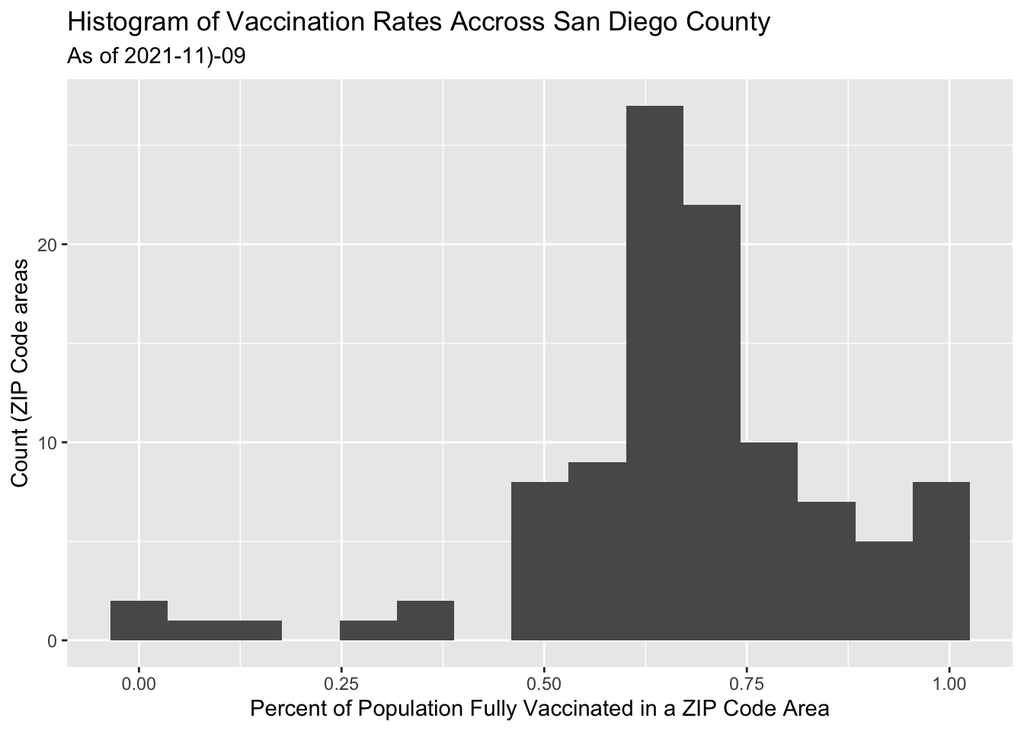

```r
library(ggplot2)

ggplot(sd.11.9) +
  aes(percent_of_population_fully_vaccinated) +
  geom_histogram(bins=15) +
  labs (x="Percent of Population Fully Vaccinated in a ZIP Code Area",
        y="Count (ZIP Code areas",
        title="Histogram of Vaccination Rates Accross San Diego County",
       subtitle="As of 2021-11)-09")
```

> *A14.** See graph above.

## Focus on UCSD/La Jolla

```r
ucsd <- filter(sd, zip_code_tabulation_area == "92037")
ucsd
```

```
##    as_of_date zip_code_tabulation_area local_health_jurisdiction    county
## 1  2021-01-05                    92037                 San Diego San Diego
## 2  2021-01-12                    92037                 San Diego San Diego
## 3  2021-01-19                    92037                 San Diego San Diego
## 4  2021-01-26                    92037                 San Diego San Diego
## 5  2021-02-02                    92037                 San Diego San Diego
## 6  2021-02-09                    92037                 San Diego San Diego
## 7  2021-02-16                    92037                 San Diego San Diego
## 8  2021-02-23                    92037                 San Diego San Diego
## 9  2021-03-02                    92037                 San Diego San Diego
## 10 2021-03-09                    92037                 San Diego San Diego
## 11 2021-03-16                    92037                 San Diego San Diego
## 12 2021-03-23                    92037                 San Diego San Diego
## 13 2021-03-30                    92037                 San Diego San Diego
## 14 2021-04-06                    92037                 San Diego San Diego
```

[output cut: 267 more lines]

```r
# Example: what is the age 5+ population in the 92037 ZIP code?
ucsd[1,]$age5_plus_population
```

```
## [1] 36144
```

> **Q15.** Using ggplot make a graph of the vaccination rate time course for the 92037 ZIP code area:

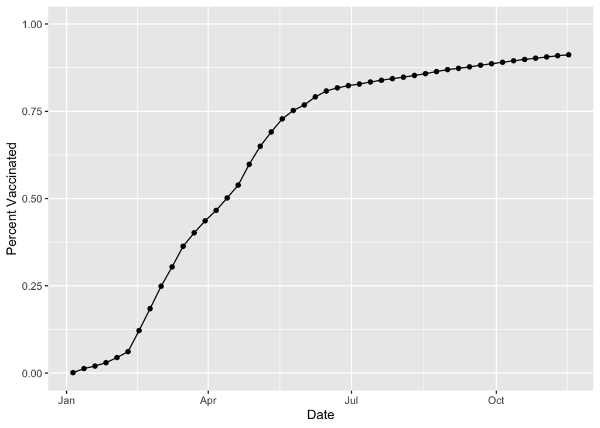

```r
ggplot(ucsd) +
  aes(x=as_of_date,
      y=percent_of_population_fully_vaccinated) +
  geom_point() +
  geom_line(groups=1) +
  ylim(c(0,1)) +
  labs(x="Date", y="Percent Vaccinated")
```

> **A15.** See graph above.

## Comparing 92037 to other similar sized areas?

```r
# Subset to all CA areas with a population as large as 92037
vax.36 <- filter(vax, age5_plus_population > 36144 &
                as_of_date == "2021-11-16")

#head(vax.36)
```

> **Q16.** Calculate the mean “Percent of Population Fully Vaccinated” for ZIP code areas with a population as large as 92037 (La Jolla) as_of_date “2021-11-16”. Add this as a straight horizontal line to your plot from above with the geom_hline() function?

```r
mean(vax.36$percent_of_population_fully_vaccinated)
```

```
## [1] 0.6629812
```

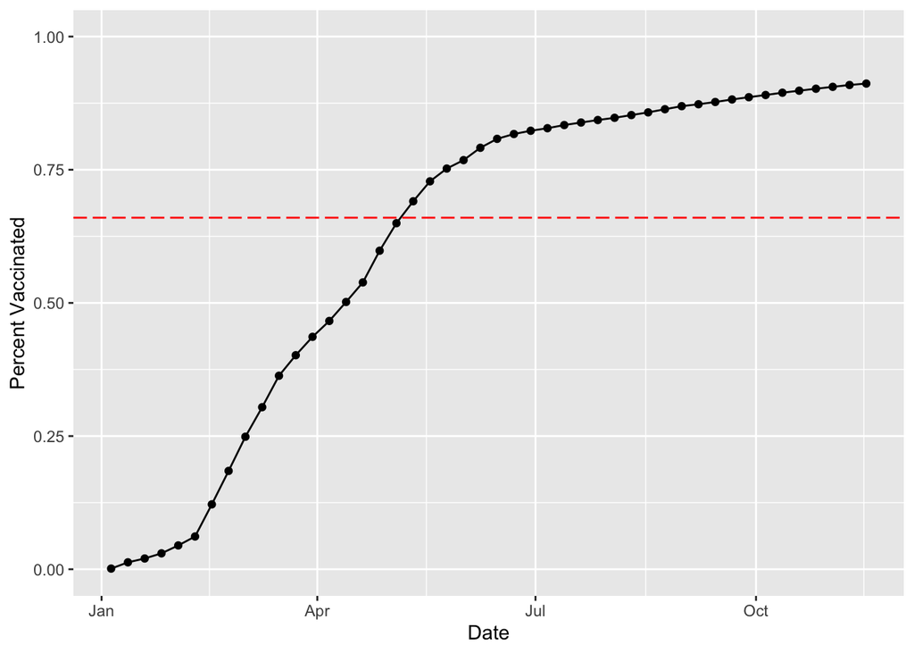

```r
ggplot(ucsd) +
  aes(x=as_of_date,
      y=percent_of_population_fully_vaccinated) +
  geom_point() +
  geom_line(groups=1) +
  ylim(c(0,1)) +
  labs(x="Date", y="Percent Vaccinated") +
  geom_hline(yintercept = 0.66, linetype="longdash", color="red")
```

> **A16.** The mean Percent of Population Fully Vaccinated for ZIP code areas with a population as large as 92037 (La Jolla) as of 2021-11-16 is approximately **66%**. This value is addded to the graph above as a red line.

> **Q17.** What is the 6 number summary (Min, 1st Qu., Median, Mean, 3rd Qu., and Max) of the “Percent of Population Fully Vaccinated” values for ZIP code areas with a population as large as 92037 (La Jolla) as_of_date “2021-11-16”?

```r
summary(vax.36$percent_of_population_fully_vaccinated)
```

```
##    Min. 1st Qu.  Median    Mean 3rd Qu.    Max.
##  0.3519  0.5891  0.6649  0.6630  0.7286  1.0000
```

> **A17.** See summary above.

> **Q18.** Using ggplot generate a histogram of this data.

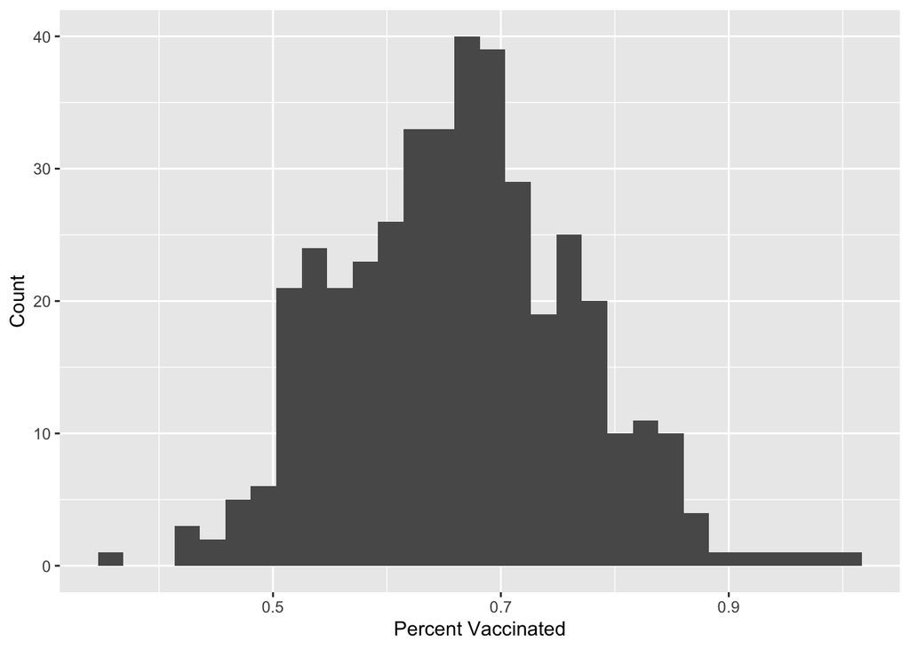

```r
ggplot(vax.36) +
  aes (x=percent_of_population_fully_vaccinated) +
  geom_histogram() +
   labs(x="Percent Vaccinated", y="Count")
```

> **A18** See graph above.

> **Q19.** Is the 92109 and 92040 ZIP code areas above or below the average value you calculated for all these above?

```r
# Print mean again
mean(vax.36$percent_of_population_fully_vaccinated)
```

```
## [1] 0.6629812
```

```r
filter(vax.36, zip_code_tabulation_area=="92109")
```

```
##   as_of_date zip_code_tabulation_area local_health_jurisdiction    county
## 1 2021-11-16                    92109                 San Diego San Diego
##   vaccine_equity_metric_quartile                 vem_source
## 1                              3 Healthy Places Index Score
##   age12_plus_population age5_plus_population persons_fully_vaccinated
## 1               43222.5                44953                    30917
##   persons_partially_vaccinated percent_of_population_fully_vaccinated
## 1                         4641                               0.687763
##   percent_of_population_partially_vaccinated
## 1                                   0.103241
##   percent_of_population_with_1_plus_dose redacted
## 1                               0.791004       No
```

```r
filter(vax.36, zip_code_tabulation_area=="92040")
```

```
##   as_of_date zip_code_tabulation_area local_health_jurisdiction    county
## 1 2021-11-16                    92040                 San Diego San Diego
##   vaccine_equity_metric_quartile                 vem_source
## 1                              3 Healthy Places Index Score
##   age12_plus_population age5_plus_population persons_fully_vaccinated
## 1                 39405                42833                    22293
##   persons_partially_vaccinated percent_of_population_fully_vaccinated
## 1                         2738                               0.520463
##   percent_of_population_partially_vaccinated
## 1                                   0.063923
##   percent_of_population_with_1_plus_dose redacted
## 1                               0.584386       No
```

> **A19.** The percent of population fully vaccinated in the **92109** ZIP code is approximately **69%**, which is higher than average of approximately 66%. The percent of population fully vaccinated in the **92040** ZIP code is approxumately **52%**, which is lower than average.

```r
colnames(vax.36)
```

```
##  [1] "as_of_date"
##  [2] "zip_code_tabulation_area"
##  [3] "local_health_jurisdiction"
##  [4] "county"
##  [5] "vaccine_equity_metric_quartile"
##  [6] "vem_source"
##  [7] "age12_plus_population"
##  [8] "age5_plus_population"
##  [9] "persons_fully_vaccinated"
## [10] "persons_partially_vaccinated"
## [11] "percent_of_population_fully_vaccinated"
## [12] "percent_of_population_partially_vaccinated"
## [13] "percent_of_population_with_1_plus_dose"
## [14] "redacted"
```

> **Q20.** Finally make a time course plot of vaccination progress for all areas in the full dataset with a age5_plus_population > 36144

First, we need to subset the full `vax` daraset to include only ZIP codes areas with a population as large as 92037.

```r
vax.36.all <- filter(vax, age5_plus_population > 36144)
nrow(vax.36.all)
```

```
## [1] 18906
```

How many unique zip codes have a population as large as 92307?

```r
length(unique(vax.36.all))
```

```
## [1] 14
```

Let’s make a final figure that shows all these ZIP areas.

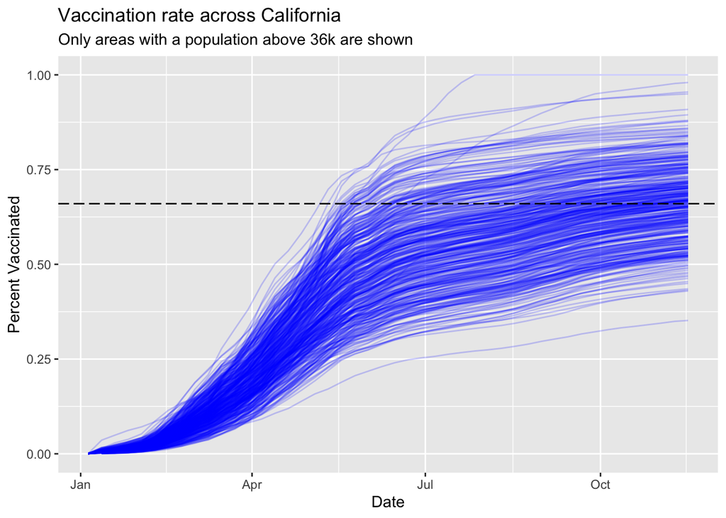

```r
ggplot(vax.36.all) +
  aes(x=as_of_date,
      y=percent_of_population_fully_vaccinated,
      group=zip_code_tabulation_area) +
  geom_line(alpha=0.2, color="blue") +
  labs(x="Date", y="Percent Vaccinated",
       title="Vaccination rate across California",
       subtitle="Only areas with a population above 36k are shown") +
  geom_hline(yintercept = 0.66, linetype="longdash")
```

> **A20.** See graph above.

> **Q21.** How do you feel about traveling for Thanksgiving and meeting for in-person class next Week?

> **A21.** I still feel comfortable travelling for Thanksgiving and meeting for in-person class, especially since I am vaccinated and I now know a lot of people in the areas I will be are also vaccinated. However, it’s always a priority to keep those around me safe, so I still tend to stay on the safe side of things, like by avoiding large crowds.

Have a great break! :)